# HW2 Mehta Notebook

Christine Mehta

# Problem 1

## Section 1: Matrix Form

```r
##Create a matrix X comprised of three columns: a column of ones, a column made up of the variable year, and a column of variable women

ones <- c(1,1,1,1,1,1,1,1,1,1,1,1,1,1,1,1,1,1,1,1,1,1,1,1,1,1,1,1,1,1,1,1,1,1,1,1,1,1,1,1,1,1)
year <- c(sprinters_data$year)
women <- c(sprinters_data$women)
X <- cbind(ones,year,women)
X
```

```
##       ones year women
##  [1,]    1 1900     0
##  [2,]    1 1904     0
##  [3,]    1 1908     0
##  [4,]    1 1912     0
##  [5,]    1 1920     0
##  [6,]    1 1924     0
##  [7,]    1 1928     0
##  [8,]    1 1932     0
##  [9,]    1 1936     0
## [10,]    1 1948     0
## [11,]    1 1952     0
## [12,]    1 1956     0
## [13,]    1 1960     0
## [14,]    1 1964     0
```

[output cut: 28 more lines]

```r
##Create a matrix y comprised of a single column, made up of the variable finish

y <- sprinters_data %>% select(finish)
y
```

```
##    finish
## 1   11.00
## 2   11.00
## 3   10.80
## 4   10.80
## 5   10.80
## 6   10.60
## 7   10.80
## 8   10.30
## 9   10.30
## 10  10.30
## 11  10.40
## 12  10.50
## 13  10.20
## 14  10.00
```

[output cut: 28 more lines]

```r
matrix_y <- as.matrix(y)
matrix_y
```

```
##       finish
##  [1,]  11.00
##  [2,]  11.00
##  [3,]  10.80
##  [4,]  10.80
##  [5,]  10.80
##  [6,]  10.60
##  [7,]  10.80
##  [8,]  10.30
##  [9,]  10.30
## [10,]  10.30
## [11,]  10.40
## [12,]  10.50
## [13,]  10.20
## [14,]  10.00
```

[output cut: 28 more lines]

```r
##Solve formula using matrix commands

A <- t(X) %*% X
A1 <- solve(A)
A2 <- X %*% A1
A3 <- t(A2) %*% matrix_y
pander(A3)
```

|  | finish |
| --- | --- |
| **ones** | 34.96 |
| **year** | -0.01261 |
| **women** | 1.093 |

## Section 2: Fitting a Linear Model

```r
lm1 <- lm(finish~year+women, data = sprinters_data)
summary(lm1)
```

```
##
## Call:
## lm(formula = finish ~ year + women, data = sprinters_data)
##
## Residuals:
##      Min       1Q   Median       3Q      Max
## -0.44623 -0.10170  0.02093  0.11094  0.45724
##
## Coefficients:
##              Estimate Std. Error t value Pr(>|t|)
## (Intercept) 34.960037   1.964903   17.79  < 2e-16 ***
## year        -0.012609   0.001005  -12.54 2.89e-15 ***
## women        1.092812   0.059502   18.37  < 2e-16 ***
## ---
## Signif. codes:  0 '***' 0.001 '**' 0.01 '*' 0.05 '.' 0.1 ' ' 1
##
## Residual standard error: 0.1852 on 39 degrees of freedom
## Multiple R-squared:  0.9125, Adjusted R-squared:  0.9081
## F-statistic: 203.5 on 2 and 39 DF,  p-value: < 2.2e-16
```

Comparison: The calculation in section 1 produced the intercept, and coefficients of the multiple regression of finish on year and women. The results are the same.

```r
##Plot the multivariate regression
sprinters_data
```

```
##    year finish women
## 1  1900  11.00     0
## 2  1904  11.00     0
## 3  1908  10.80     0
## 4  1912  10.80     0
## 5  1920  10.80     0
## 6  1924  10.60     0
## 7  1928  10.80     0
## 8  1932  10.30     0
## 9  1936  10.30     0
## 10 1948  10.30     0
## 11 1952  10.40     0
## 12 1956  10.50     0
## 13 1960  10.20     0
## 14 1964  10.00     0
```

[output cut: 28 more lines]

```r
preds <- predict(lm1, interval = "confidence")
preds
```

```
##          fit       lwr       upr
## 1  11.003004 10.868660 11.137347
## 2  10.952568 10.824828 11.080307
## 3  10.902132 10.780811 11.023453
## 4  10.851696 10.736576 10.966816
## 5  10.750824 10.647301 10.854348
## 6  10.700389 10.602166 10.798611
## 7  10.649953 10.556622 10.743283
## 8  10.599517 10.510602 10.688432
## 9  10.549081 10.464032 10.634130
## 10 10.397773 10.320252 10.475295
## 11 10.347338 10.270746 10.423929
## 12 10.296902 10.220382 10.373422
## 13 10.246466 10.169158 10.323774
## 14 10.196030 10.117099 10.274961
```

[output cut: 28 more lines]

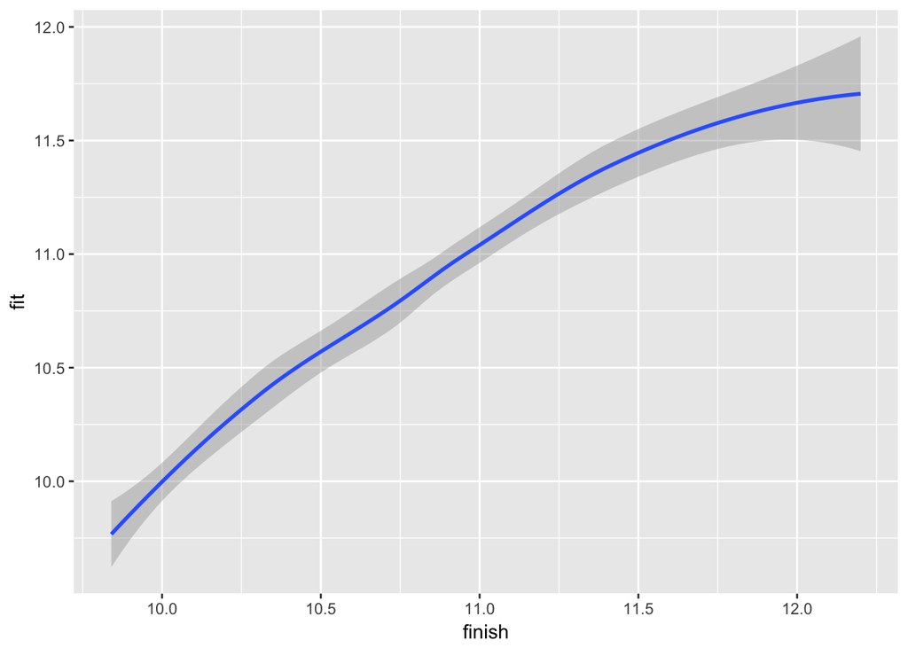

```r
pred_plot <- cbind(sprinters_data, preds)

ggplot(pred_plot, aes(x = finish, y = fit, ymin = lwr, ymax=upr)) +
  geom_smooth()
```

```r
lm2 <- lm(finish ~ women + year + women*year, data=sprinters_data)
summary(lm2)
```

```
##
## Call:
## lm(formula = finish ~ women + year + women * year, data = sprinters_data)
##
## Residuals:
##      Min       1Q   Median       3Q      Max
## -0.37579 -0.05460  0.00738  0.08276  0.32234
##
## Coefficients:
##              Estimate Std. Error t value Pr(>|t|)
## (Intercept) 31.826453   2.128910  14.950  < 2e-16 ***
## women       12.520596   4.076141   3.072  0.00392 **
## year        -0.011006   0.001089 -10.104 2.56e-12 ***
## women:year  -0.005817   0.002074  -2.804  0.00791 **
## ---
## Signif. codes:  0 '***' 0.001 '**' 0.01 '*' 0.05 '.' 0.1 ' ' 1
##
## Residual standard error: 0.1707 on 38 degrees of freedom
## Multiple R-squared:  0.9275, Adjusted R-squared:  0.9218
## F-statistic: 162.1 on 3 and 38 DF,  p-value: < 2.2e-16
```

```r
predict(lm2
        )
```

```
##         1         2         3         4         5         6         7
## 10.915886 10.871863 10.827841 10.783819 10.695774 10.651752 10.607730
##         8         9        10        11        12        13        14
## 10.563708 10.519685 10.387619 10.343596 10.299574 10.255552 10.211530
##        15        16        17        18        19        20        21
## 10.167507 10.123485 10.079463 10.035441  9.991418  9.947396  9.903374
##        22        23        24        25        26        27        28
##  9.859352  9.815329  9.771307 11.914098 11.846809 11.779521 11.577656
##        29        30        31        32        33        34        35
## 11.510368 11.443080 11.375791 11.308503 11.241215 11.173926 11.106638
##        36        37        38        39        40        41        42
## 11.039350 10.972062 10.904773 10.837485 10.770197 10.702908 10.635620
```

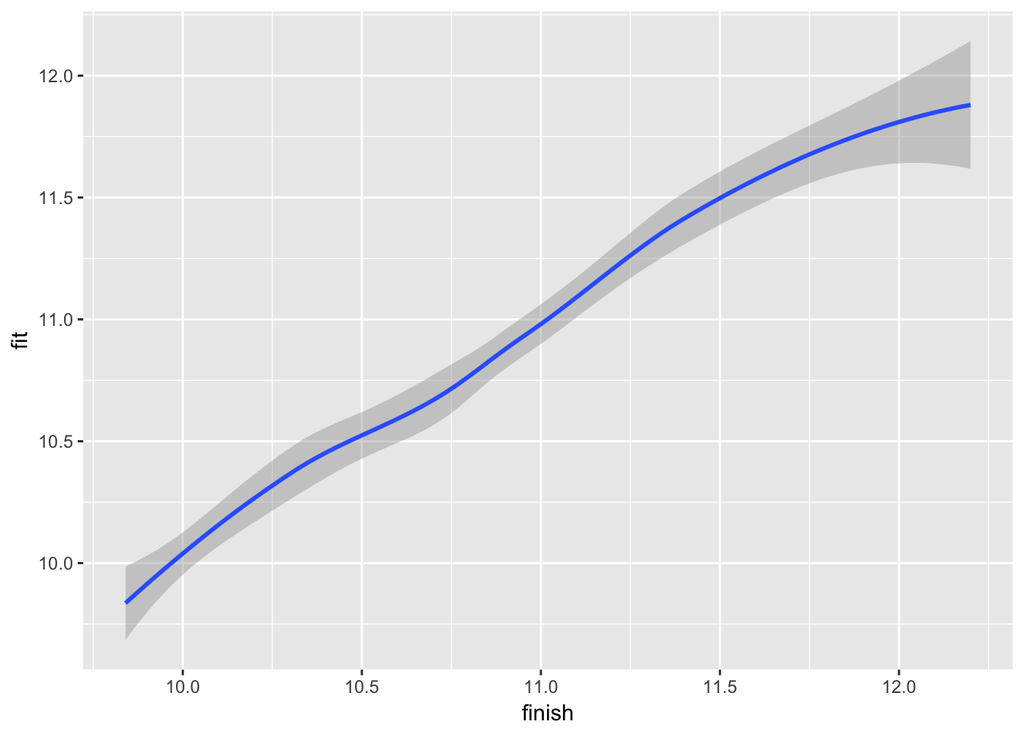

```r
preds <- predict(lm2, sprinters_data, interval = "confidence", level = 0.95)

pred_plot2 <- cbind(preds, sprinters_data)

ggplot(pred_plot2, aes(x = finish, y = fit, ymin=lwr, ymax = upr)) +
  geom_smooth()
```

## Section 3: Predicted Values

```r
## Men and Women's finishing times in 2001

hyp <- data_frame(year = 2001, women = 0)
hyp2 <- data_frame(year = 2001, women = 1)
predict(lm2, hyp, interval = "confidence")
```

```
##        fit      lwr      upr
## 1 9.804324 9.679561 9.929086
```

```r
predict(lm2, hyp2, interval = "confidence")
```

```
##        fit      lwr      upr
## 1 10.68609 10.54469 10.82748
```

```r
##Finishing times for the year 2156 for men and women

hyp3 <- data_frame(year = 2156, women = 0)
hyp4 <- data_frame(year = 2156, women = 1)
predict(lm2, hyp3, interval = "confidence")
```

```
##        fit      lwr      upr
## 1 8.098462 7.648238 8.548686
```

```r
predict(lm2, hyp4, interval = "confidence")
```

```
##        fit      lwr      upr
## 1 8.078666 7.404166 8.753165
```

The predicted finishing time for men in the year 2156 is 8.1 seconds (CI lower = 7.65, CI upper = 8.55). The women’s predicted finishing time would be 8.08 seconds (CI lower = 7.4, CI upper = 8.8).

Do I trust the model’s predictions? Yes, I do given the strong linear nature of the data and the strength of the model. However, I trust the 2001 result more than than the 2156 prediction as 2001 is a data point much closer to the data within our model and so I would expect that 2001 has a very low probability of being an outlier and therefore likely to fall within the model - whereas year 2156 is further from the data within the model.

```r
hyp5 <- data_frame(year = 3000, women = 0)
hyp6 <- data_frame(year = 3000, women = 1)
predict(lm2, hyp5, interval = "confidence")
```

```
##         fit       lwr      upr
## 1 -1.190232 -3.496937 1.116472
```

```r
predict(lm2, hyp6, interval = "confidence")
```

```
##         fit       lwr       upr
## 1 -6.119162 -9.806223 -2.432101
```

The assumption that finishing times will continue to decrease in a linear way is overworked in this model given that the model can’t account for the limits of human capacity in running. Certainly, we can see in this model that finishing by actually gaining time is impossible - and so the model clearly falls apart in predicting this far out into the future.

# Problem 2

## Section 4: Looking at your data beyond summary statistics

```r
## calculate mean and standard deviations of x and y

mean(anscombe2$x)
```

```
## [1] 9
```

```r
sd(anscombe2$x)
```

```
## [1] 3.198837
```

```r
mean(anscombe2$y)
```

```
## [1] 7.500682
```

```r
sd(anscombe2$y)
```

```
## [1] 1.958925
```

```r
##Run a linear regression between x and y for each data set

## Dataset 1
dataset1 <- anscombe2 %>% filter(dataset == 1)

lm_dataset1 <- lm(x ~ y, data = dataset1)
summary(lm_dataset1)
```

```
##
## Call:
## lm(formula = x ~ y, data = dataset1)
##
## Residuals:
##     Min      1Q  Median      3Q     Max
## -2.6522 -1.5117 -0.2657  1.2341  3.8946
##
## Coefficients:
##             Estimate Std. Error t value Pr(>|t|)
## (Intercept)  -0.9975     2.4344  -0.410  0.69156
## y             1.3328     0.3142   4.241  0.00217 **
## ---
## Signif. codes:  0 '***' 0.001 '**' 0.01 '*' 0.05 '.' 0.1 ' ' 1
##
## Residual standard error: 2.019 on 9 degrees of freedom
## Multiple R-squared:  0.6665, Adjusted R-squared:  0.6295
## F-statistic: 17.99 on 1 and 9 DF,  p-value: 0.00217
```

```r
##Dataset 2
dataset2 <- anscombe2 %>% filter(dataset == 2)

lm_dataset2 <- lm(x ~ y, data = dataset2)
summary(lm_dataset2)
```

```
##
## Call:
## lm(formula = x ~ y, data = dataset2)
##
## Residuals:
##     Min      1Q  Median      3Q     Max
## -1.8516 -1.4315 -0.3440  0.8467  4.2017
##
## Coefficients:
##             Estimate Std. Error t value Pr(>|t|)
## (Intercept)  -0.9948     2.4354  -0.408  0.69246
## y             1.3325     0.3144   4.239  0.00218 **
## ---
## Signif. codes:  0 '***' 0.001 '**' 0.01 '*' 0.05 '.' 0.1 ' ' 1
##
## Residual standard error: 2.02 on 9 degrees of freedom
## Multiple R-squared:  0.6662, Adjusted R-squared:  0.6292
## F-statistic: 17.97 on 1 and 9 DF,  p-value: 0.002179
```

```r
##Dataset 3
dataset3 <- anscombe2 %>% filter(dataset == 3)

lm_dataset3 <- lm(x ~ y, data = dataset3)
summary(lm_dataset3)
```

```
##
## Call:
## lm(formula = x ~ y, data = dataset3)
##
## Residuals:
##     Min      1Q  Median      3Q     Max
## -2.9869 -1.3733 -0.0266  1.3200  3.2133
##
## Coefficients:
##             Estimate Std. Error t value Pr(>|t|)
## (Intercept)  -1.0003     2.4362  -0.411  0.69097
## y             1.3334     0.3145   4.239  0.00218 **
## ---
## Signif. codes:  0 '***' 0.001 '**' 0.01 '*' 0.05 '.' 0.1 ' ' 1
##
## Residual standard error: 2.019 on 9 degrees of freedom
## Multiple R-squared:  0.6663, Adjusted R-squared:  0.6292
## F-statistic: 17.97 on 1 and 9 DF,  p-value: 0.002176
```

```r
##Dataset 4
dataset4 <- anscombe2 %>% filter(dataset == 4)

lm_dataset4 <- lm(x ~ y, data = dataset4)
summary(lm_dataset4)
```

```
##
## Call:
## lm(formula = x ~ y, data = dataset4)
##
## Residuals:
##     Min      1Q  Median      3Q     Max
## -2.7859 -1.4122 -0.1853  1.4551  3.3329
##
## Coefficients:
##             Estimate Std. Error t value Pr(>|t|)
## (Intercept)  -1.0036     2.4349  -0.412  0.68985
## y             1.3337     0.3143   4.243  0.00216 **
## ---
## Signif. codes:  0 '***' 0.001 '**' 0.01 '*' 0.05 '.' 0.1 ' ' 1
##
## Residual standard error: 2.018 on 9 degrees of freedom
## Multiple R-squared:  0.6667, Adjusted R-squared:  0.6297
## F-statistic:    18 on 1 and 9 DF,  p-value: 0.002165
```

I would expect them to look similar as the regression results are very similar - however, I suspect they will not as summary statistics do not tell us what the data actually looks like! The fit of our model could be the same for many different types of datasets.

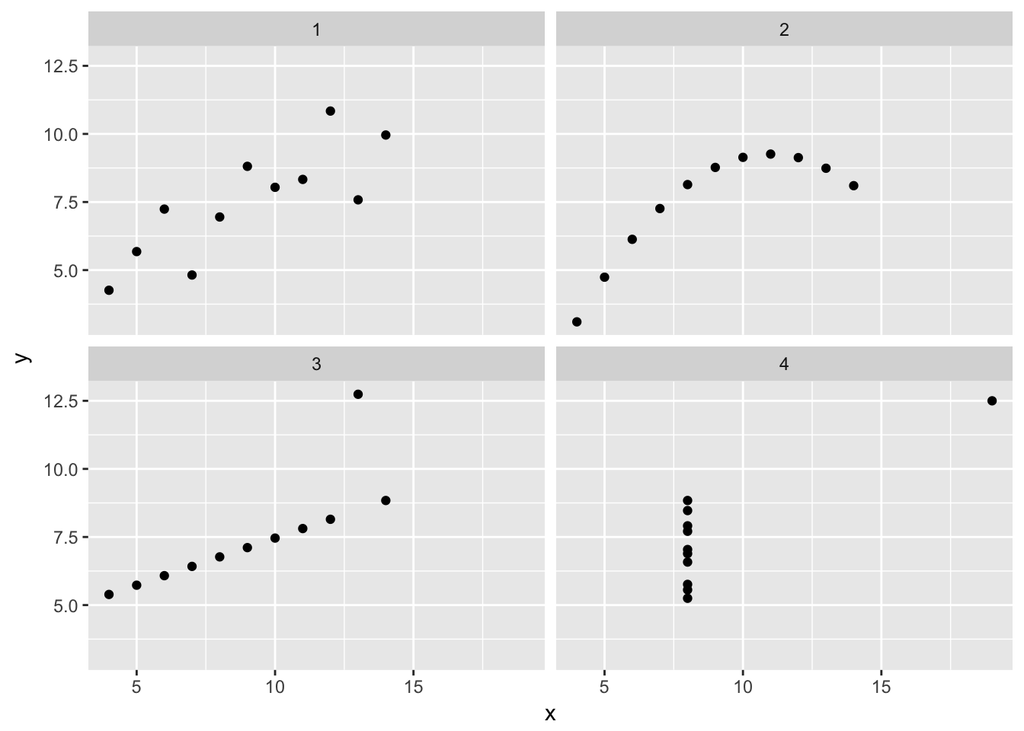

```r
##Scatterplot of each dataset

ggplot(anscombe2, aes(x = x, y = y)) +
  geom_point()+
  facet_wrap(~dataset)
```

As I suspected, the regression model fit the data in all four datasets similar because the same regression line was the best fit for all four sets of these data even though they are obviously very different data, with sets 1 and 3 being the only two with data demonstrating a strong linear relationship.

# Problem 3